# 3. Consolidate

Arnold Kakas

2023-12-12

## Úvod

V tomto blogu sa budem venovať **Exploratory Data Analysis (EDA)** čiže úvodnej analýze údajov, ktorej cieľom je zistiť aká je kvalita, obsah a štruktúra údajov. V tomto prípade ide o dáta z inzercií nehnuteľností. Dáta sú scrape-nuté z webu [Nehnutelnosti](https://www.nehnutelnosti.sk/). Podrobnejšie som prešiel procesom webscraping-u v mojom predchádzajúcom blogovom príspevku.  
Komentáre v kódoch ponechávam v angličtine, je to best practice najmä ak pracujete v medzinárodnom prostredí.

## EDA

**Exploratory Data Analysis** je neoddeliteľnou súčasťou dátovej analytiky (Data analysis)/dátovej vedy (Data science).

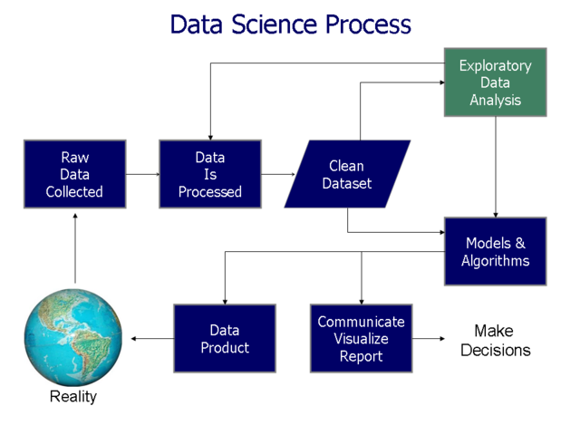

Účelom EDA je zhrnúť hlavné charakteristiky súboru údajov (ako kvalita, obsah a štruktúra), objaviť vzorce a vzťahy medzi premennými a identifikovať trendy. Malo by nás to viesť k pochopeniu údajov a identifikácii kritických premenných vzhľadom na naše ciele. Ako je znázornené na obrázku, ide o iteratívny proces. Na základe vašich zistení môžete buď pokračovať v modelovaní/testovaní hypotéz a reportovaní, alebo sa vrátiť k čisteniu/spracovaniu údajov.  
EDA zvyčajne začína načítaním údajov a kontrolou niekoľkých riadkov, aby ste získali prvotný “pocit” z údajov spolu s kontrolou štruktúry údajov, veľkosti vzorky, typov údajov, chýbajúcich hodnôt atď. Potom pokračujeme podrobnejšou analýzou čo nám pomáha pochopiť vzťahy a identifikovať odľahlé hodnoty a dôležité premenné. V EDA používame rôzne techniky a nástroje. Vo všeobecnosti ich možno rozdeliť do niekoľkých skupín:

- Súhrnné (jednopremenné) štatistiky - min, max, priemer, medián, kvartily, IQR, štandardná odchýlka, počty, frekvencia atď.
- Vizualizácia dát - histogram, boxplot, Paretov graf, bodové grafy, korelačná matica, čiarové grafy (pre časové rady), heatmapy atď.
- Bi-/viacpremenné štatistiky - korelácia, t-test, chí-kvadrát test, ANOVA, Kruskal-Wallisov test atď.

Nakoniec na základe zistení vytvoríme záver a buď pokračujeme v projekte, alebo sa vrátime k dodatočnému upratovaniu dát.  
Aj keď radšej robím EDA manuálne, existuje niekoľko R knižníc pre automatizované EDA. Sú užitočné pri prvotnom skúmaní údajov a identifikácii napr. dátových typov, premenných s veľkou časťou chýbajúcich hodnôt a iných “high-level” charakteristík. Sú to napríklad knižnice:

- DataExplorer
- ExPanDaR
- dataMaid
- dlookr

## Čistenie dát

Pre načítanie knižníc rád používam knižnicu [packman](https://cran.r-project.org/web/packages/pacman/index.html).

```r
# import libraries
if (!require("pacman")) {
  install.packages("pacman")
}

pacman::p_load(
  tidyverse,
  janitor,
  skimr,
  sf,
  ggmap,
  colorRamps,
  plotly,
  spdep,
  # rgeos,
  # rgdal,
  sfdep
)
```

Nasleduje prvotné čistenie dát. v nasledujúcom kóde spájam 3 rôzne súbory.

```r
# Load advertisements data from RDS file
advertisements <- readRDS("data/advertisements.RDS")

# Clean and restructure advertisements data
advertisements <- advertisements %>%
  separate(type_of_real_estate, c("type", "area"), sep = " • ", remove = TRUE) %>%
  select(link, type)

# Load and process districts mapping data from Excel file
districts_mapping <- openxlsx::read.xlsx("data/obce_okresy.xlsx") %>%
  mutate(
    municipality = str_replace(municipality, "Košice - ", "Košice - mestská časť "),
    municipality = str_replace(municipality, "Bratislava - ", "Bratislava - mestská časť ")
  )

# Load and process scraped data with geocoding
scraped_data <- readRDS("data/advertisements_complete_geocoded.RDS") %>%
  filter(!is.na(link)) %>%
  select(-c(address1, address2, info_text, district, municipality, address)) %>%
  rename(quality_of_living = quanlity_of_living) %>%
  mutate(
    NAME_NSI = str_replace(NAME_NSI, "Hodruša-Hámre", "Hodruša - Hámre"),
    NAME_NSI = str_replace(NAME_NSI, "Perín-Chym", "Perín - Chym"),
    NAME_NSI = str_replace(NAME_NSI, "Šaštín-Stráže", "Šaštín - Stráže"),
    NAME_NSI = str_replace(NAME_NSI, "Kostolná-Záriečie", "Kostolná - Záriečie")
  )

# Join advertisements and scraped data
joined_data <- scraped_data %>%
  left_join(advertisements, by = "link", multiple = "first", keep = FALSE) %>%
  clean_names() %>%
  mutate(
    # Convert relevant columns to numeric format
    pocet_izieb_miestnosti = as.numeric(pocet_izieb_miestnosti),
    uzit_plocha = str_replace(str_replace(uzit_plocha, ",", "."), " m2", ""),
    energie = str_replace(str_replace(energie, ",", "."), " €/mesiac", ""),
    provizia_zahrnuta_v_cene = str_replace_na(provizia_zahrnuta_v_cene, "Nie"),
    # Create a 'rooms' column based on 'type' and handle missing values
    rooms = case_when(type == "1 izbový byt" ~ 1,
      type == "2 izbový byt" ~ 2,
      type == "3 izbový byt" ~ 3,
      type == "4 izbový byt" ~ 4,
      type == "5 a viac izbový byt" ~ 5,
      type == "Garsónka" ~ 1,
      type == "Dvojgarsónka" ~ 2,
      .default = NA
    ),
    pocet_izieb_miestnosti = coalesce(pocet_izieb_miestnosti, rooms, pocet_izieb_miestnosti)
  ) %>%
  mutate_at(c(
    "index_of_living",
    "uzit_plocha",
    "energie",
    "pocet_nadzemnych_podlazi",
    "podlazie",
    "pocet_izieb_miestnosti",
    "rok_vystavby",
    "rok_poslednej_rekonstrukcie",
    "pocet_balkonov",
    "pocet_lodzii"
  ), as.numeric) %>%
  select(-link) %>%
  filter(pocet_izieb_miestnosti < 10 & !is.na(pocet_izieb_miestnosti)) %>%
  mutate(
    type = coalesce(type, case_when(
      pocet_izieb_miestnosti == 1 ~ "1 izbový byt",
      pocet_izieb_miestnosti == 2 ~ "2 izbový byt",
      pocet_izieb_miestnosti == 3 ~ "3 izbový byt",
      pocet_izieb_miestnosti == 4 ~ "4 izbový byt",
      pocet_izieb_miestnosti >= 5 ~ "5 a viac izbový byt"
    ))
  ) %>%
  select(-rooms) %>%
  filter(!(type %in% c("Apartmán", "Mezonet", "Iný byt", "Loft"))) %>%
  mutate(
    # Recreate 'rooms' column after filtering and handle missing values
    rooms = case_when(type == "1 izbový byt" ~ 1,
      type == "2 izbový byt" ~ 2,
      type == "3 izbový byt" ~ 3,
      type == "4 izbový byt" ~ 4,
      type == "5 a viac izbový byt" ~ 5,
      type == "Garsónka" ~ 1,
      type == "Dvojgarsónka" ~ 2,
      .default = NA
    )
  ) %>%
  select(-pocet_izieb_miestnosti) %>%
  mutate(
    # Convert relevant columns to numeric format
    across(c(
      "environment", "safety", "transport", "relax", "quality_of_living", "services"
    ), na_if, "0"),
    across(c(
      "environment", "safety", "transport", "relax", "quality_of_living", "services"
    ), as.numeric)
  ) %>%
  rename(index = index_of_living,
         condition = stav,
         area = uzit_plocha,
         provision = provizia_zahrnuta_v_cene,
         certificate = energeticky_certifikat,
         energy_costs = energie,
         construction_type = typ_konstrukcie,
         year_built = rok_vystavby,
         last_reconstruction = rok_poslednej_rekonstrukcie,
         total_floors = pocet_nadzemnych_podlazi,
         floor = podlazie,
         lift = vytah,
         balkonies = pocet_balkonov,
         loggia = pocet_lodzii,
         cellar = pivnica,
         orientation = orientacia
  )

# Join with districts mapping data
joined_data <- joined_data %>%
  left_join(districts_mapping, join_by(name_nsi == municipality), keep = FALSE, multiple = "first")

# Create a copy of joined data without geometry information
joined_data_wo_geom <- joined_data
joined_data_wo_geom$geometry <- NULL
```

## EDA

Prvý krok v EDA je pozrieť sa na dáta ako celok. V jazyku R môžeme použiť napr. základnú funkciu `summary()`. Ja osobne používam rád funkciu `skim()` z knižnice skimr.

```r
skim(joined_data_wo_geom)
```

Data summary

| Name | joined_data_wo_geom |
| --- | --- |
| Number of rows | 15619 |
| Number of columns | 27 |
| _______________________ |  |
| Column type frequency: |  |
| character | 10 |
| numeric | 17 |
| ________________________ |  |
| Group variables | None |

**Variable type: character**

| skim_variable | n_missing | complete_rate | min | max | empty | n_unique | whitespace |
| --- | --- | --- | --- | --- | --- | --- | --- |
| name_nsi | 0 | 1.00 | 3 | 46 | 0 | 598 | 0 |
| condition | 329 | 0.98 | 10 | 23 | 0 | 6 | 0 |
| provision | 0 | 1.00 | 3 | 3 | 0 | 2 | 0 |
| certificate | 8992 | 0.42 | 1 | 4 | 0 | 8 | 0 |
| construction_type | 13251 | 0.15 | 3 | 23 | 0 | 11 | 0 |
| orientation | 14595 | 0.07 | 5 | 14 | 0 | 8 | 0 |
| lift | 11421 | 0.27 | 3 | 3 | 0 | 1 | 0 |
| cellar | 15391 | 0.01 | 3 | 3 | 0 | 1 | 0 |
| type | 0 | 1.00 | 8 | 19 | 0 | 7 | 0 |
| district | 0 | 1.00 | 4 | 20 | 0 | 79 | 0 |

**Variable type: numeric**

| skim_variable | n_missing | complete_rate | mean | sd | p0 | p25 | p50 | p75 | p100 | hist |
| --- | --- | --- | --- | --- | --- | --- | --- | --- | --- | --- |
| price | 216 | 0.99 | 165205.67 | 162973.63 | 11500.0 | 99900.0 | 136900.00 | 190000.0 | 9936000.0 | ▇▁▁▁▁ |
| index | 10442 | 0.33 | 7.79 | 0.95 | 3.3 | 7.3 | 8.00 | 8.5 | 9.5 | ▁▁▃▇▇ |
| environment | 11474 | 0.27 | 7.83 | 0.94 | 2.7 | 7.3 | 8.00 | 8.4 | 10.0 | ▁▁▂▇▂ |
| quality_of_living | 11474 | 0.27 | 8.77 | 0.89 | 2.7 | 8.4 | 9.00 | 9.4 | 10.0 | ▁▁▁▃▇ |
| safety | 11474 | 0.27 | 8.05 | 1.99 | 2.0 | 7.2 | 8.70 | 9.5 | 10.0 | ▁▁▂▃▇ |
| transport | 11474 | 0.27 | 8.40 | 1.43 | 2.0 | 7.7 | 8.60 | 9.3 | 10.0 | ▁▁▁▃▇ |
| services | 11474 | 0.27 | 7.96 | 1.57 | 2.0 | 7.2 | 8.40 | 9.2 | 10.0 | ▁▁▂▅▇ |
| relax | 11474 | 0.27 | 5.70 | 1.75 | 2.0 | 4.5 | 5.80 | 7.1 | 9.5 | ▃▇▇▇▃ |
| area | 721 | 0.95 | 104.11 | 2571.22 | 1.0 | 51.5 | 64.62 | 77.0 | 209900.0 | ▇▁▁▁▁ |
| energy_costs | 14638 | 0.06 | 150.58 | 52.31 | 20.0 | 110.0 | 150.00 | 190.0 | 365.0 | ▂▇▅▁▁ |
| year_built | 11692 | 0.25 | 1903.21 | 496.12 | 1.0 | 1972.0 | 1981.00 | 2021.0 | 19741.0 | ▇▁▁▁▁ |
| last_reconstruction | 14936 | 0.04 | 2018.30 | 6.01 | 1968.0 | 2016.0 | 2020.00 | 2023.0 | 2024.0 | ▁▁▁▁▇ |
| total_floors | 8264 | 0.47 | 5.60 | 3.65 | 1.0 | 3.0 | 5.00 | 8.0 | 46.0 | ▇▁▁▁▁ |
| floor | 7128 | 0.54 | 3.51 | 2.62 | -7.0 | 2.0 | 3.00 | 5.0 | 34.0 | ▂▇▁▁▁ |
| balkonies | 13738 | 0.12 | 1.11 | 0.38 | 1.0 | 1.0 | 1.00 | 1.0 | 6.0 | ▇▁▁▁▁ |
| loggia | 14099 | 0.10 | 1.11 | 0.36 | 1.0 | 1.0 | 1.00 | 1.0 | 5.0 | ▇▁▁▁▁ |
| rooms | 0 | 1.00 | 2.48 | 0.89 | 1.0 | 2.0 | 3.00 | 3.0 | 5.0 | ▃▇▇▂▁ |

```r
mun_ind <- joined_data_wo_geom %>%
  group_by(name_nsi) %>%
  summarize(index = mean(index, na.rm = TRUE))

skimr::skim(mun_ind)
```

Data summary

| Name | mun_ind |
| --- | --- |
| Number of rows | 598 |
| Number of columns | 2 |
| _______________________ |  |
| Column type frequency: |  |
| character | 1 |
| numeric | 1 |
| ________________________ |  |
| Group variables | None |

**Variable type: character**

| skim_variable | n_missing | complete_rate | min | max | empty | n_unique | whitespace |
| --- | --- | --- | --- | --- | --- | --- | --- |
| name_nsi | 0 | 1 | 3 | 46 | 0 | 598 | 0 |

**Variable type: numeric**

| skim_variable | n_missing | complete_rate | mean | sd | p0 | p25 | p50 | p75 | p100 | hist |
| --- | --- | --- | --- | --- | --- | --- | --- | --- | --- | --- |
| index | 456 | 0.24 | 6.98 | 1.29 | 3.3 | 6.1 | 7.22 | 8.01 | 9 | ▁▃▇▇▇ |

```r
# price where we have index
mun_ind_price <- joined_data_wo_geom %>%
  filter(!is.na(index)) %>%
  group_by(name_nsi) %>%
  summarize(price = mean(price, na.rm = TRUE))

skim(mun_ind_price)
```

Data summary

| Name | mun_ind_price |
| --- | --- |
| Number of rows | 142 |
| Number of columns | 2 |
| _______________________ |  |
| Column type frequency: |  |
| character | 1 |
| numeric | 1 |
| ________________________ |  |
| Group variables | None |

**Variable type: character**

| skim_variable | n_missing | complete_rate | min | max | empty | n_unique | whitespace |
| --- | --- | --- | --- | --- | --- | --- | --- |
| name_nsi | 0 | 1 | 4 | 46 | 0 | 142 | 0 |

**Variable type: numeric**

| skim_variable | n_missing | complete_rate | mean | sd | p0 | p25 | p50 | p75 | p100 | hist |
| --- | --- | --- | --- | --- | --- | --- | --- | --- | --- | --- |
| price | 0 | 1 | 159948.9 | 65385.35 | 23000 | 113791.7 | 153976.4 | 193002 | 425664 | ▃▇▃▁▁ |

```r
# price where we dont have index
mun_no_ind_price <- joined_data_wo_geom %>%
  filter(is.na(index)) %>%
  group_by(name_nsi) %>%
  summarize(price = mean(price, na.rm = TRUE))

skim(mun_no_ind_price)
```

Data summary

| Name | mun_no_ind_price |
| --- | --- |
| Number of rows | 567 |
| Number of columns | 2 |
| _______________________ |  |
| Column type frequency: |  |
| character | 1 |
| numeric | 1 |
| ________________________ |  |
| Group variables | None |

**Variable type: character**

| skim_variable | n_missing | complete_rate | min | max | empty | n_unique | whitespace |
| --- | --- | --- | --- | --- | --- | --- | --- |
| name_nsi | 0 | 1 | 3 | 46 | 0 | 567 | 0 |

**Variable type: numeric**

| skim_variable | n_missing | complete_rate | mean | sd | p0 | p25 | p50 | p75 | p100 | hist |
| --- | --- | --- | --- | --- | --- | --- | --- | --- | --- | --- |
| price | 0 | 1 | 117100 | 65050.52 | 19200 | 78129.46 | 105813.3 | 141991.7 | 888888 | ▇▁▁▁▁ |

```r
mun_check <- joined_data_wo_geom %>%
  group_by(name_nsi) %>%
  mutate(index2 = mean(index, na.rm = TRUE),
         price = mean(price, na.rm = TRUE)) %>%
  ungroup

skimr::skim(mun_check)
```

Data summary

| Name | mun_check |
| --- | --- |
| Number of rows | 15619 |
| Number of columns | 28 |
| _______________________ |  |
| Column type frequency: |  |
| character | 10 |
| numeric | 18 |
| ________________________ |  |
| Group variables | None |

**Variable type: character**

| skim_variable | n_missing | complete_rate | min | max | empty | n_unique | whitespace |
| --- | --- | --- | --- | --- | --- | --- | --- |
| name_nsi | 0 | 1.00 | 3 | 46 | 0 | 598 | 0 |
| condition | 329 | 0.98 | 10 | 23 | 0 | 6 | 0 |
| provision | 0 | 1.00 | 3 | 3 | 0 | 2 | 0 |
| certificate | 8992 | 0.42 | 1 | 4 | 0 | 8 | 0 |
| construction_type | 13251 | 0.15 | 3 | 23 | 0 | 11 | 0 |
| orientation | 14595 | 0.07 | 5 | 14 | 0 | 8 | 0 |
| lift | 11421 | 0.27 | 3 | 3 | 0 | 1 | 0 |
| cellar | 15391 | 0.01 | 3 | 3 | 0 | 1 | 0 |
| type | 0 | 1.00 | 8 | 19 | 0 | 7 | 0 |
| district | 0 | 1.00 | 4 | 20 | 0 | 79 | 0 |

**Variable type: numeric**

| skim_variable | n_missing | complete_rate | mean | sd | p0 | p25 | p50 | p75 | p100 | hist |
| --- | --- | --- | --- | --- | --- | --- | --- | --- | --- | --- |
| price | 0 | 1.00 | 165760.45 | 75287.92 | 19200.0 | 117187.46 | 153825.75 | 207528.27 | 888888.0 | ▇▃▁▁▁ |
| index | 10442 | 0.33 | 7.79 | 0.95 | 3.3 | 7.30 | 8.00 | 8.50 | 9.5 | ▁▁▃▇▇ |
| environment | 11474 | 0.27 | 7.83 | 0.94 | 2.7 | 7.30 | 8.00 | 8.40 | 10.0 | ▁▁▂▇▂ |
| quality_of_living | 11474 | 0.27 | 8.77 | 0.89 | 2.7 | 8.40 | 9.00 | 9.40 | 10.0 | ▁▁▁▃▇ |
| safety | 11474 | 0.27 | 8.05 | 1.99 | 2.0 | 7.20 | 8.70 | 9.50 | 10.0 | ▁▁▂▃▇ |
| transport | 11474 | 0.27 | 8.40 | 1.43 | 2.0 | 7.70 | 8.60 | 9.30 | 10.0 | ▁▁▁▃▇ |
| services | 11474 | 0.27 | 7.96 | 1.57 | 2.0 | 7.20 | 8.40 | 9.20 | 10.0 | ▁▁▂▅▇ |
| relax | 11474 | 0.27 | 5.70 | 1.75 | 2.0 | 4.50 | 5.80 | 7.10 | 9.5 | ▃▇▇▇▃ |
| area | 721 | 0.95 | 104.11 | 2571.22 | 1.0 | 51.50 | 64.62 | 77.00 | 209900.0 | ▇▁▁▁▁ |
| energy_costs | 14638 | 0.06 | 150.58 | 52.31 | 20.0 | 110.00 | 150.00 | 190.00 | 365.0 | ▂▇▅▁▁ |
| year_built | 11692 | 0.25 | 1903.21 | 496.12 | 1.0 | 1972.00 | 1981.00 | 2021.00 | 19741.0 | ▇▁▁▁▁ |
| last_reconstruction | 14936 | 0.04 | 2018.30 | 6.01 | 1968.0 | 2016.00 | 2020.00 | 2023.00 | 2024.0 | ▁▁▁▁▇ |
| total_floors | 8264 | 0.47 | 5.60 | 3.65 | 1.0 | 3.00 | 5.00 | 8.00 | 46.0 | ▇▁▁▁▁ |
| floor | 7128 | 0.54 | 3.51 | 2.62 | -7.0 | 2.00 | 3.00 | 5.00 | 34.0 | ▂▇▁▁▁ |
| balkonies | 13738 | 0.12 | 1.11 | 0.38 | 1.0 | 1.00 | 1.00 | 1.00 | 6.0 | ▇▁▁▁▁ |
| loggia | 14099 | 0.10 | 1.11 | 0.36 | 1.0 | 1.00 | 1.00 | 1.00 | 5.0 | ▇▁▁▁▁ |
| rooms | 0 | 1.00 | 2.48 | 0.89 | 1.0 | 2.00 | 3.00 | 3.00 | 5.0 | ▃▇▇▂▁ |
| index2 | 4096 | 0.74 | 7.83 | 0.68 | 3.3 | 7.58 | 7.99 | 8.23 | 9.0 | ▁▁▁▆▇ |

```r
mun_check_ind_price <- mun_check %>%
  filter(!is.na(index2)) %>%
  group_by(name_nsi) %>%
  summarize(price = mean(price, na.rm = TRUE))

skim(mun_check_ind_price)
```

Data summary

| Name | mun_check_ind_price |
| --- | --- |
| Number of rows | 142 |
| Number of columns | 2 |
| _______________________ |  |
| Column type frequency: |  |
| character | 1 |
| numeric | 1 |
| ________________________ |  |
| Group variables | None |

**Variable type: character**

| skim_variable | n_missing | complete_rate | min | max | empty | n_unique | whitespace |
| --- | --- | --- | --- | --- | --- | --- | --- |
| name_nsi | 0 | 1 | 4 | 46 | 0 | 142 | 0 |

**Variable type: numeric**

| skim_variable | n_missing | complete_rate | mean | sd | p0 | p25 | p50 | p75 | p100 | hist |
| --- | --- | --- | --- | --- | --- | --- | --- | --- | --- | --- |
| price | 0 | 1 | 154151.1 | 62591.57 | 23000 | 111287.5 | 145007.5 | 187452.6 | 416349.8 | ▃▇▃▁▁ |

```r
dist_ind <- joined_data_wo_geom %>%
  group_by(district) %>%
  summarize(index = mean(index, na.rm = TRUE))

skimr::skim(dist_ind)
```

Data summary

| Name | dist_ind |
| --- | --- |
| Number of rows | 79 |
| Number of columns | 2 |
| _______________________ |  |
| Column type frequency: |  |
| character | 1 |
| numeric | 1 |
| ________________________ |  |
| Group variables | None |

**Variable type: character**

| skim_variable | n_missing | complete_rate | min | max | empty | n_unique | whitespace |
| --- | --- | --- | --- | --- | --- | --- | --- |
| district | 0 | 1 | 4 | 20 | 0 | 79 | 0 |

**Variable type: numeric**

| skim_variable | n_missing | complete_rate | mean | sd | p0 | p25 | p50 | p75 | p100 | hist |
| --- | --- | --- | --- | --- | --- | --- | --- | --- | --- | --- |
| index | 31 | 0.61 | 7.61 | 0.9 | 4.8 | 7.26 | 7.8 | 8.25 | 8.9 | ▁▁▂▇▆ |

```r
# keep only municipalities with at least 5 ads
# number_of_ads <- scraped_cleaned_wo_geometry %>%
#   group_by(name_nsi) %>%
#   tally() %>%
#   arrange(n)
#
# scraped_cleaned <- scraped_cleaned %>%
#   left_join(number_of_ads, by = "name_nsi", keep = FALSE) %>%
#   filter(n > 4)
#
# relevant_mun <- number_of_ads %>%
#   filter(n > 4) %>%
#   select(1)
#
# saveRDS(relevant_mun, file = "data/app_obce_filter_list.rds")
```

```r
# scraped_cleaned_wo_outliers <- scraped_cleaned %>%
#   filter(!is.na(price)) %>%
#   group_by(name_nsi) %>%
#   mutate(index = mean(as.numeric(index),na.rm = TRUE),
#          index = if_else(index > 0, index, NA),
#          IQR = IQR(price),
#          median = median(price),
#          lower = median - 1.5*IQR,
#          upper = median + 1.5*IQR,
#          ) %>%
#   ungroup() %>%
#   filter(price >= lower & price <= upper) %>%
#   select(-lower, -upper, -median, -IQR) %>%
#   left_join(index_district, by = "district", multiple = "first", keep = FALSE)

# scraped_cleaned_final <- scraped_cleaned %>%
#   left_join(index_district, by = "district", multiple = "first", keep = FALSE)
```

```r
#
# district_mean_index <- scraped_data %>% group_by(name) %>% summarize(i = mean(as.numeric(index_of_living),na.rm = TRUE))
#
# district_mean_index$x[is.nan(district_mean_index$i)] <- NA
# district_mean_index$x <- ifelse(district_mean_index$x == 0.000000, NA, district_mean_index$x)
# district_mean_index$x.check <- district_mean_index$x
#
#
# x <- 1
# n <- 5
# nb.districts <- st_contiguity(district_mean_index)
# weight <- st_weights(nb.districts)
# while (i <= n) {
# district_mean_index$lag.x <- st_lag(district_mean_index$x, nb.districts, weight, na_ok = TRUE)
# district_mean_index <- district_mean_index %>%
#   mutate(x = coalesce(x, lag.x)) %>%
#   select(-lag.x)
#
# i = i + 1
#
# }
```

```r
# rm(list = setdiff(ls(), "scraped_cleaned_final")) # scraped_cleaned_wo_outliers
#
# gc()
```

```r
# districts <- readRDS("data/geospatial_data/districts.RDS")
#
# scraped_cleaned_final <- scraped_cleaned_final %>% st_centroid()
#
# advertisements_complete_districts_geocoded <- districts %>%
#   st_join(scraped_cleaned_final, join = st_contains) %>%
#   select(-municipality, -district) %>%
#   rename(district = NAME) %>%
#   mutate(
#     district = as_factor(district),
#     condition = as_factor(condition),
#     type = as_factor(type),
#     provision = as_factor(provision),
#     certificate = as_factor(certificate),
#     name_nsi = as_factor(name_nsi)
#   )
```

```r
# save data for models
# final_data <- advertisements_complete_districts_geocoded
#
# final_data$geometry <- NULL
#
# saveRDS(final_data, file = "data/apartments_final_data.rds")
```

```r
# rm(list = ls())
#
# gc()
```

```r
# apartments_final_data <- read_rds("data/apartments_final_data.rds")
```

```r
# index_districts <- apartments_final_data %>%
#   mutate(index = if_else(index > 0, index, NA)) %>%
#   select(district, index_mean_district) %>%
#   distinct() %>%
#   group_by(district) %>%
#   summarize(index_mean_district = mean(index_mean_district, na.rm = TRUE))
#
# saveRDS(index_districts, "data/index_districts.RDS")
```